# Plants Seedling Classification - Project Work

### Context

- In recent times, the field of agriculture has been in urgent need of modernizing, since the amount of manual work people need to put in to check if plants are growing correctly is still highly extensive. Despite several advances in agricultural technology, people working in the agricultural industry still need to have the ability to sort and recognize different plants and weeds, which takes a lot of time and effort in the long term.
- The potential is ripe for this trillion-dollar industry to be greatly impacted by technological innovations that cut down on the requirement for manual labor, and this is where Artificial Intelligence can benefit the workers in this field, as the time and energy required to identify plant seedlings will be greatly shortened by the use of AI and Deep Learning. The ability to do so far more efficiently and even more effectively than experienced manual labor could lead to better crop yields, the freeing up of human involvement for higher-order agricultural decision making, and in the long term will result in more sustainable environmental practices in agriculture as well.
- As a data scientist, you have to create an efficient model to classify these images into their respective categories.

#### Objective

- Build a Convolutional Neural Network model which would classify the plant seedlings into their respective 12 categories.

#### Data Description

- This dataset contains images of unique plants belonging to 12 different species. The data file names are: images.npy Label.csv
- The goal of the project is to create a classifier capable of determining a plant's species from an image.
- List of Plant species

1.Black-grass 2.Charlock 3.Cleavers 4.Common Chickweed 5.Common Wheat 6.Fat Hen 7.Loose Silky-bent 8.Maize 9.Scentless Mayweed 10.Shepherds Purse 11.Small-flowered Cranesbill 12.Sugar beet

#### Approach:

- I have visualyzed the data, performed EDA. Applied one hot encoding, normalizing (to scale 0-1).
- I've built 4 models - CNN, after applying data-augmentation on train data, without applying weights and Transfer learning (VGG).
- For each model created model evaluation graph, confusion matrix and provided my insight.
- I have not used google colab hence I did not use cv2_imshow (commented out). But after conversion to RGB from BGR, I visualized the image.
- Finally I ended the project with my conclusions.

##### Importing the necessary libraries

```python
# This will help in making the Python code more structured automatically
%load_ext nb_black

import os
import numpy as np  # Importing numpy for Matrix Operations
import pandas as pd  # Importing pandas to read CSV files
import matplotlib.pyplot as plt  # Importting matplotlib for Plotting and visualizing images
import math  # Importing math module to perform mathematical operations
import cv2  # Importing openCV for image processing
import seaborn as sns  # Importing seaborn to plot graphs


# Tensorflow modules
import tensorflow as tf
from tensorflow.keras.preprocessing.image import (
    ImageDataGenerator,
)  # Importing the ImageDataGenerator for data augmentation
from tensorflow.keras.models import (
    Sequential,
)  # Importing the sequential module to define a sequential model
from tensorflow.keras.layers import (
    Dense,
    Dropout,
    Flatten,
    Conv2D,
    MaxPooling2D,
    BatchNormalization,
)  # Defining all the layers to build our CNN Model
from tensorflow.keras.optimizers import (
    Adam,
    SGD,
)  # Importing the optimizers which can be used in our model
from sklearn import (
    preprocessing,
)  # Importing the preprocessing module to preprocess the data
from sklearn.model_selection import (
    train_test_split,
)  # Importing train_test_split function to split the data into train and test
from sklearn.metrics import confusion_matrix

# Display images using OpenCV
# from google.colab.patches import cv2_imshow

# Ignore warnings
import warnings

warnings.filterwarnings("ignore")
```

#### Loading both images and lables of the dataset

```python
# Load the image file of the dataset
images = np.load("images.npy")

# Load the labels file of the dataset
labels = pd.read_csv("Labels.csv")
```

#### Overview of the dataset

```python
print(images.shape)
print(labels.shape)
```

```
(4750, 128, 128, 3)
(4750, 1)
```

- There are 4750 RGB images of shape 128 x 128 X 3, each image having 3 channels.

#### Plotting images using OpenCV and matplotlib

```python
images[5]
```

```
array([[[ 32,  34,  48],
        [ 28,  28,  43],
        [ 29,  32,  50],
        ...,
        [ 38,  49,  66],
        [ 40,  53,  68],
        [ 37,  50,  65]],

       [[ 23,  23,  37],
        [ 27,  26,  38],
        [ 24,  33,  48],
        ...,
        [ 36,  50,  65],
        [ 39,  54,  67],
        [ 35,  49,  63]],

       [[ 25,  24,  37],
        [ 24,  23,  36],
        [ 17,  28,  46],
        ...,
        [ 35,  49,  65],
        [ 35,  50,  64],
        [ 33,  48,  64]],

       ...,

       [[ 57,  80, 100],
        [ 56,  79, 101],
        [ 53,  77, 100],
        ...,
        [ 55,  76,  92],
        [ 55,  78,  96],
        [ 59,  81, 100]],

       [[ 54,  77,  97],
        [ 59,  81, 103],
        [ 52,  76,  99],
        ...,
        [ 58,  80,  95],
        [ 59,  83,  99],
        [ 61,  84, 103]],

       [[ 58,  81, 102],
        [ 59,  81, 102],
        [ 62,  85, 106],
        ...,
        [ 56,  79,  93],
        [ 55,  80,  97],
        [ 56,  80, 100]]], dtype=uint8)
```

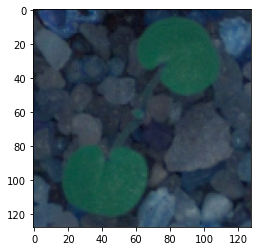

```python
plt.imshow(images[5])
```

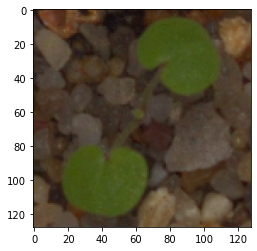

```python
rgb_img = cv2.cvtColor(images[5], cv2.COLOR_BGR2RGB)  # this converts it into RGB

plt.imshow(rgb_img)
plt.show()
```

- After converting to RGB the image looks much better. I'm going to do same for rest of the images in the dataset
- converting these BGR images to RGB images so it could be easier to interpret them.

```python
# Converting the images from BGR to RGB using cvtColor function of OpenCV
for i in range(len(images)):
    images[i] = cv2.cvtColor(images[i], cv2.COLOR_BGR2RGB)
```

### Exploratory Data Analysis¶

```python
def plot_images(images, labels):
    num_classes = 12  # Number of Classes
    categories = np.unique(labels)
    keys = dict(labels["Label"])  # Obtaing the unique classes from y_train
    rows = 3  # Defining number of rows=3
    cols = 4  # Defining number of columns=4
    fig = plt.figure(figsize=(10, 8))  # Defining the figure size to 10x8
    for i in range(cols):
        for j in range(rows):
            random_index = np.random.randint(
                0, len(labels)
            )  # Generating random indices from the data and plotting the images
            ax = fig.add_subplot(
                rows, cols, i * rows + j + 1
            )  # Adding subplots with 3 rows and 4 columns
            ax.imshow(images[random_index, :])  # Plotting the image
            ax.set_title(keys[random_index])
    plt.show()
```

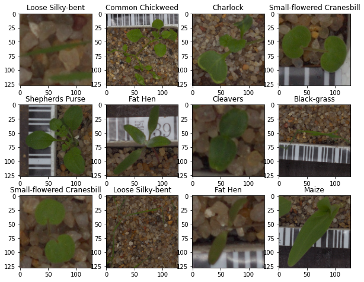

```python
# Plotting the images from each class and print their corresponding labels.
plot_images(images, labels)
```

#### Checking for data imbalance

[output not shown]

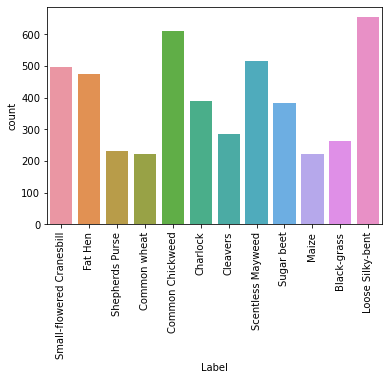

```python
sns.countplot(labels["Label"])
plt.xticks(rotation="vertical")
```

#### Resizing images

- To address the computationally expensive issue while training on these larger images, I'm going to reduce image size from 128 to 64.

```python
images_decreased = []
height = 64
width = 64
dimensions = (width, height)
for i in range(len(images)):
    images_decreased.append(
        cv2.resize(images[i], dimensions, interpolation=cv2.INTER_LINEAR)
    )
```

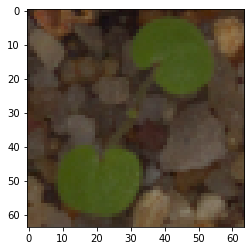

```python
plt.imshow(images_decreased[5])
```

- After reduced the image, the image is slightly blurred.

##### Visualizing images using Gaussian Blur

```python
# Applying Gaussian Blur to denoise the images
images_gb=[]
for i in range(len(images)):
  images_gb.append(cv2.GaussianBlur(images[i], ksize =(3,3),sigmaX =  0))
```

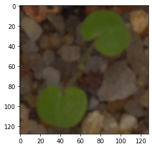

```python
plt.imshow(images_gb[5])
```

- I'm not seeing any improvement after applied Gaussian Blur
- It appears that GaussianBlur would be ineffective because the blurred or denoised image does not seem to contain any relevant information, and the model would struggle to categorize these blurred images.

#### Splitting the dataset

- Splitting the dataset into three parts, train,test and validation using train_test_split function from sklearn

```python
from sklearn.model_selection import train_test_split

X_temp, X_test, y_temp, y_test = train_test_split(
    np.array(images_decreased), labels, test_size=0.1, random_state=42, stratify=labels
)
X_train, X_val, y_train, y_val = train_test_split(
    X_temp, y_temp, test_size=0.1, random_state=42, stratify=y_temp
)
```

```python
print(X_train.shape, y_train.shape)
print(X_val.shape, y_val.shape)
print(X_test.shape, y_test.shape)
```

```
(3847, 64, 64, 3) (3847, 1)
(428, 64, 64, 3) (428, 1)
(475, 64, 64, 3) (475, 1)
```

#### Making the data compatible by applying these three techniques.

- Convert labels from names to one hot vectors
- Normalizing the values
- Treat the class imbalance by increasing the weights of the minority classes.

##### Adjusting weights for minority classes

```python
from sklearn.utils import class_weight

labelList = labels.Label.unique()
class_weights = class_weight.compute_class_weight(
    class_weight="balanced", classes=np.array(labelList), y=y_train.values.reshape(-1)
)
class_weights = dict(zip(np.array(range(len(labelList))), class_weights))
# print calculated class weights
class_weights
```

```
{0: 0.7974709784411277,
 1: 0.8348524305555556,
 2: 1.714349376114082,
 3: 1.7909683426443204,
 4: 0.6476430976430977,
 5: 1.0145042194092826,
 6: 1.3818247126436782,
 7: 0.7669457735247209,
 8: 1.0275106837606838,
 9: 1.7909683426443204,
 10: 1.5050860719874803,
 11: 0.604874213836478}
```

##### Encoding the target labels

```python
# Convert labels from names to one hot vectors.
# We have already used encoding methods like onehotencoder and labelencoder earlier so now we will be using a new encoding method called labelBinarizer.
# Labelbinarizer works similar to onehotencoder

from sklearn.preprocessing import LabelBinarizer

enc = LabelBinarizer()
y_train_encoded = enc.fit_transform(y_train)
y_val_encoded = enc.transform(y_val)
y_test_encoded = enc.transform(y_test)
```

```python
print(y_train_encoded)
print(y_val_encoded)
print(y_test_encoded)
```

```
[[0 0 0 ... 1 0 0]
 [0 0 0 ... 0 0 0]
 [0 0 0 ... 0 1 0]
 ...
 [0 0 0 ... 0 0 0]
 [0 0 0 ... 0 0 0]
 [0 0 0 ... 1 0 0]]
[[0 0 0 ... 0 0 0]
 [0 0 0 ... 0 0 0]
 [0 1 0 ... 0 0 0]
 ...
 [0 0 0 ... 0 0 0]
 [0 0 0 ... 0 0 0]
 [0 0 0 ... 0 0 0]]
[[0 0 0 ... 0 0 0]
 [0 0 0 ... 0 1 0]
 [0 0 0 ... 0 1 0]
 ...
 [0 0 0 ... 0 0 0]
 [0 0 0 ... 0 0 0]
 [0 0 0 ... 1 0 0]]
```

#### Data Normalization

- Dividing all the pixel values by 255 to standardize the images to have values between 0-1.

```python
# Normalizing the image pixels
X_train_normalized = X_train.astype("float32") / 255.0
X_val_normalized = X_val.astype("float32") / 255.0
X_test_normalized = X_test.astype("float32") / 255.0
```

```python
print(X_train_normalized)
print(X_val_normalized)
print(X_test_normalized)
```

[output not shown]

[output cut: 866 more lines]

[output not shown]

#### Model Building - Convolutional Neural Network (CNN)

- Creating a CNN model sequentially by adding the layers one after another.
- Clearing the previous model's history from the session even if a single model can run multiple times on the same data and fixing the seed again after clearing the backend.
- Set the seed for random number generators in Numpy this helps to reproduce the same results every time when run the code.

```python
# Clearing backend
from tensorflow.keras import backend

backend.clear_session()
```

```python
# Fixing the seed for random number generators
import random

np.random.seed(42)
random.seed(42)
tf.random.set_seed(42)
```

```python
# to ignore the following issue, I'm setting enviroment
"""tensorflow/core/platform/cpu_feature_guard.cc:193] This TensorFlow binary is
#optimized with oneAPI Deep Neural Network Library (oneDNN) to use the following CPU instructions in performance-critical operations:  AVX2 AVX512F AVX512_VNNI FMA
#To enable them in other operations, rebuild TensorFlow with the appropriate compiler flags"""

os.environ["TF_CPP_MIN_LOG_LEVEL"] = "2"
```

- Building a CNN Model with the following 2 main parts -
1. The Feature Extraction layers which are comprised of convolutional and pooling layers.
2. The Fully Connected classification layers for prediction.

```python
# Intializing a sequential model1
model1 = Sequential()

# Adding first conv layer with 64 filters and kernel size 3x3 , padding 'same' provides the output size same as the input size
# Input_shape denotes input image dimension of images
model1.add(
    Conv2D(64, (3, 3), activation="relu", padding="same", input_shape=(64, 64, 3))
)

# Adding max pooling to reduce the size of output of first conv layer
model1.add(MaxPooling2D((2, 2), padding="same"))

model1.add(Conv2D(32, (3, 3), activation="relu", padding="same"))
model1.add(MaxPooling2D((2, 2), padding="same"))

# flattening the output of the conv layer after max pooling to make it ready for creating dense connections
model1.add(Flatten())

# Adding a fully connected dense layer with 100 neurons
model1.add(Dense(16, activation="relu"))
model1.add(Dropout(0.3))

# Adding the output layer with 12neurons and activation functions as softmax since this is a multi-class classification problem
model1.add(Dense(12, activation="softmax"))

# using Adam optimizer and categorical_crossentropy as loss function with accuracy as metrics.
opt = Adam()

# Compile model1
model1.compile(optimizer=opt, loss="categorical_crossentropy", metrics=["accuracy"])

# Generating the summary of the model1
model1.summary()
```

```
Model: "sequential"
_________________________________________________________________
 Layer (type)                Output Shape              Param #
=================================================================
 conv2d (Conv2D)             (None, 64, 64, 64)        1792

 max_pooling2d (MaxPooling2D  (None, 32, 32, 64)       0
 )

 conv2d_1 (Conv2D)           (None, 32, 32, 32)        18464

 max_pooling2d_1 (MaxPooling  (None, 16, 16, 32)       0
 2D)

 flatten (Flatten)           (None, 8192)              0

 dense (Dense)               (None, 16)                131088

 dropout (Dropout)           (None, 16)                0

 dense_1 (Dense)             (None, 12)                204

=================================================================
Total params: 151,548
Trainable params: 151,548
Non-trainable params: 0
_________________________________________________________________
```

- There are about 151,548 are trainable parameters with this model.

#### Fitting the model on the train data

```python
history_1 = model1.fit(
    X_train_normalized,
    y_train_encoded,
    epochs=30,
    validation_data=(X_val_normalized, y_val_encoded),
    batch_size=32,
    class_weight=class_weights,
    verbose=2,
)
```

```
121/121 - 11s - loss: 2.9401 - accuracy: 0.1115 - val_loss: 2.4666 - val_accuracy: 0.1215 - 11s/epoch - 92ms/step
121/121 - 11s - loss: 2.6620 - accuracy: 0.2137 - val_loss: 2.1571 - val_accuracy: 0.2500 - 11s/epoch - 91ms/step
121/121 - 12s - loss: 2.4581 - accuracy: 0.2529 - val_loss: 2.0202 - val_accuracy: 0.3154 - 12s/epoch - 98ms/step
121/121 - 11s - loss: 2.3294 - accuracy: 0.2594 - val_loss: 1.9130 - val_accuracy: 0.3388 - 11s/epoch - 92ms/step
121/121 - 11s - loss: 2.2988 - accuracy: 0.2571 - val_loss: 1.8437 - val_accuracy: 0.3505 - 11s/epoch - 94ms/step
121/121 - 12s - loss: 2.2150 - accuracy: 0.2792 - val_loss: 1.7739 - val_accuracy: 0.3855 - 12s/epoch - 95ms/step
121/121 - 11s - loss: 2.1697 - accuracy: 0.3062 - val_loss: 1.7280 - val_accuracy: 0.3949 - 11s/epoch - 92ms/step
121/121 - 11s - loss: 2.1139 - accuracy: 0.3174 - val_loss: 1.6971 - val_accuracy: 0.4112 - 11s/epoch - 88ms/step
121/121 - 11s - loss: 2.0984 - accuracy: 0.3153 - val_loss: 1.7168 - val_accuracy: 0.4229 - 11s/epoch - 91ms/step
121/121 - 12s - loss: 2.0760 - accuracy: 0.3244 - val_loss: 1.7036 - val_accuracy: 0.4603 - 12s/epoch - 101ms/step
121/121 - 11s - loss: 2.0392 - accuracy: 0.3312 - val_loss: 1.6682 - val_accuracy: 0.4393 - 11s/epoch - 87ms/step
121/121 - 11s - loss: 2.0976 - accuracy: 0.3104 - val_loss: 1.6256 - val_accuracy: 0.4322 - 11s/epoch - 88ms/step
121/121 - 11s - loss: 2.0468 - accuracy: 0.3099 - val_loss: 1.6167 - val_accuracy: 0.4486 - 11s/epoch - 87ms/step
121/121 - 11s - loss: 2.0353 - accuracy: 0.3161 - val_loss: 1.6190 - val_accuracy: 0.4603 - 11s/epoch - 94ms/step
121/121 - 11s - loss: 2.0202 - accuracy: 0.3153 - val_loss: 1.6530 - val_accuracy: 0.4346 - 11s/epoch - 93ms/step
121/121 - 11s - loss: 1.9918 - accuracy: 0.3218 - val_loss: 1.5621 - val_accuracy: 0.4439 - 11s/epoch - 88ms/step
121/121 - 11s - loss: 1.9824 - accuracy: 0.3257 - val_loss: 1.5797 - val_accuracy: 0.4673 - 11s/epoch - 90ms/step
121/121 - 11s - loss: 1.9856 - accuracy: 0.3301 - val_loss: 1.5574 - val_accuracy: 0.4556 - 11s/epoch - 88ms/step
121/121 - 11s - loss: 1.9696 - accuracy: 0.3257 - val_loss: 1.5636 - val_accuracy: 0.4790 - 11s/epoch - 95ms/step
121/121 - 11s - loss: 1.9572 - accuracy: 0.3369 - val_loss: 1.5443 - val_accuracy: 0.4673 - 11s/epoch - 95ms/step
121/121 - 12s - loss: 1.9438 - accuracy: 0.3382 - val_loss: 1.5370 - val_accuracy: 0.4650 - 12s/epoch - 96ms/step
121/121 - 11s - loss: 1.9243 - accuracy: 0.3449 - val_loss: 1.5770 - val_accuracy: 0.4813 - 11s/epoch - 94ms/step
121/121 - 11s - loss: 1.9269 - accuracy: 0.3426 - val_loss: 1.5474 - val_accuracy: 0.4696 - 11s/epoch - 91ms/step
121/121 - 11s - loss: 1.9132 - accuracy: 0.3475 - val_loss: 1.5059 - val_accuracy: 0.4953 - 11s/epoch - 89ms/step
121/121 - 14s - loss: 1.8920 - accuracy: 0.3499 - val_loss: 1.4806 - val_accuracy: 0.5117 - 14s/epoch - 112ms/step
121/121 - 13s - loss: 1.9101 - accuracy: 0.3512 - val_loss: 1.4964 - val_accuracy: 0.5000 - 13s/epoch - 105ms/step
121/121 - 11s - loss: 1.9035 - accuracy: 0.3538 - val_loss: 1.6433 - val_accuracy: 0.4696 - 11s/epoch - 92ms/step
121/121 - 11s - loss: 1.8772 - accuracy: 0.3598 - val_loss: 1.5250 - val_accuracy: 0.4930 - 11s/epoch - 93ms/step
121/121 - 11s - loss: 1.8920 - accuracy: 0.3592 - val_loss: 1.4781 - val_accuracy: 0.4953 - 11s/epoch - 90ms/step
121/121 - 11s - loss: 1.8796 - accuracy: 0.3566 - val_loss: 1.4648 - val_accuracy: 0.4953 - 11s/epoch - 89ms/step
```

##### Model Evaluation

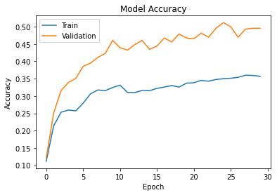

```python
plt.plot(history_1.history["accuracy"])
plt.plot(history_1.history["val_accuracy"])
plt.title("Model Accuracy")
plt.ylabel("Accuracy")
plt.xlabel("Epoch")
plt.legend(["Train", "Validation"], loc="upper left")
plt.show()
```

##### Evaluating the model on test data

```python
accuracy = model1.evaluate(X_test_normalized, y_test_encoded, verbose=2)
```

```
15/15 - 0s - loss: 1.5372 - accuracy: 0.4884 - 348ms/epoch - 23ms/step
```

- Accuracy on test data is around 0.4884.

##### Generating the predictions using test data

```python
# output as probablities for each category
y_pred = model1.predict(X_test_normalized)
```

```python
y_pred
```

```
array([[1.2789527e-05, 1.3213390e-09, 2.4130560e-07, ..., 3.9185047e-02,
        3.3337026e-09, 1.8732528e-03],
       [2.7442147e-06, 3.6212511e-02, 9.9168473e-04, ..., 1.8292844e-01,
        5.2533442e-01, 3.3624087e-02],
       [3.2533396e-06, 3.7751626e-02, 1.1040519e-03, ..., 1.8333499e-01,
        5.2025300e-01, 3.4567147e-02],
       ...,
       [1.6148181e-01, 6.9978947e-09, 9.5101917e-04, ..., 3.2470179e-10,
        8.3883691e-08, 1.6572531e-02],
       [2.2560174e-02, 1.8414172e-03, 1.8746804e-02, ..., 1.0948990e-01,
        1.1502110e-03, 5.0522666e-02],
       [2.2303264e-03, 5.5895671e-02, 3.5577785e-02, ..., 2.1545556e-01,
        1.0327862e-01, 9.2624322e-02]], dtype=float32)
```

#### Plotting the Confusion Matrix

- The Confusion matrix is defined as an inbuilt function in the TensorFlow module, using that for evaluating the classification model.
- The Confusion matrix expects categorical data as input. However, y_test_encoded is an encoded value, whereas y_pred has probabilities. so it is better to retrieve the categorical values from the encoded values.
- here argmax() function helps to obtain the maximum value over each category on both y_test_encoded and y_pred and obtain their respective classes.

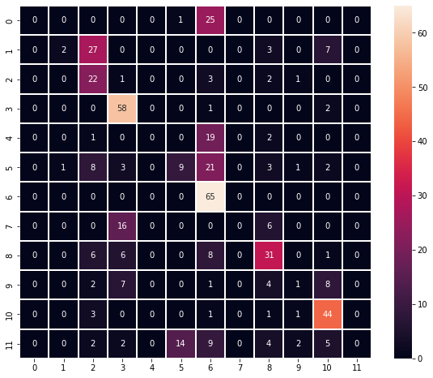

```python
# Obtaining the categorical values from y_test_encoded and y_pred
y_pred_arg = np.argmax(y_pred, axis=1)
y_test_arg = np.argmax(y_test_encoded, axis=1)

# Plotting the Confusion Matrix using confusion matrix() function which is also predefined tensorflow module
confusion_matrix = tf.math.confusion_matrix(y_test_arg, y_pred_arg)
f, ax = plt.subplots(figsize=(10, 8))
sns.heatmap(confusion_matrix, annot=True, linewidths=0.4, fmt="d", square=True, ax=ax)
plt.show()
```

#### Model-2

##### Data Augmentation

- Why we need to applu Data Augmentation?: in most of the real-world case studies, it is challenging to acquire a large number of images and then train CNNs. To overcome this problem, one approach might consider is Data Augmentation. CNNs have the property of translational invariance, which means they can recognise an object even if its appearance shifts translationally in some way. Taking this attribute into account, can augment the images using the techniques listed
- can augment the images using the techniques listed below -
1. Horizontal Flip (should be set to True/False)
2. Vertical Flip (should be set to True/False)
3. Height Shift (should be between 0 and 1)
4. Width Shift (should be between 0 and 1)
5. Rotation (should be between 0 and 180)
6. Shear (should be between 0 and 1)
7. Zoom (should be between 0 and 1) etc.

```python
# Clearing backend
from tensorflow.keras import backend

backend.clear_session()

# Fixing the seed for random number generators
import random

np.random.seed(42)
random.seed(42)
tf.random.set_seed(42)
```

- I have only used data augmentation on Train data but not test data.

```python
# All images to be rescaled by 1/255.
train_datagen = ImageDataGenerator(
    horizontal_flip=True,
    vertical_flip=False,
    height_shift_range=0.1,
    width_shift_range=0.1,
    rotation_range=20,
    shear_range=0.1,
    zoom_range=0.1,
)
```

```python
# Intializing a sequential model2
model2 = Sequential()

# Adding first conv layer with 64 filters and kernel size 3x3 , padding 'same' provides the output size same as the input size
# Input_shape denotes input image dimension images
model2.add(
    Conv2D(64, (3, 3), activation="relu", padding="same", input_shape=(64, 64, 3))
)

# Adding max pooling to reduce the size of output of first conv layer
model2.add(MaxPooling2D((2, 2), padding="same"))

# Applying BatchNormalization
model2.add(Conv2D(32, (3, 3), activation="relu", padding="same"))
model2.add(MaxPooling2D((2, 2), padding="same"))
model2.add(BatchNormalization())

# flattening the output of the conv layer after max pooling to make it ready for creating dense connections
model2.add(Flatten())

# Applying dropout
model2.add(Dense(16, activation="relu"))
model2.add(Dropout(0.3))

# Adding the output layer with 12 neurons and activation functions as softmax since this is a multi-class classification problem
model2.add(Dense(12, activation="softmax"))

# Using Adam Optimizer, categorical_crossentropy as loss function
opt = Adam()
# Compile model2
model2.compile(optimizer=opt, loss="categorical_crossentropy", metrics=["accuracy"])

# Generating the summary of the model2
model2.summary()
```

```
Model: "sequential"
_________________________________________________________________
 Layer (type)                Output Shape              Param #
=================================================================
 conv2d (Conv2D)             (None, 64, 64, 64)        1792

 max_pooling2d (MaxPooling2D  (None, 32, 32, 64)       0
 )

 conv2d_1 (Conv2D)           (None, 32, 32, 32)        18464

 max_pooling2d_1 (MaxPooling  (None, 16, 16, 32)       0
 2D)

 batch_normalization (BatchN  (None, 16, 16, 32)       128
 ormalization)

 flatten (Flatten)           (None, 8192)              0

 dense (Dense)               (None, 16)                131088

 dropout (Dropout)           (None, 16)                0

 dense_1 (Dense)             (None, 12)                204

=================================================================
Total params: 151,676
Trainable params: 151,612
Non-trainable params: 64
_________________________________________________________________
```

```python
# Epochs
epochs = 25
# Batch size
batch_size = 64

history = model2.fit(
    train_datagen.flow(
        X_train_normalized,
        y_train_encoded,
        batch_size=batch_size,
        seed=42,
        shuffle=False,
    ),
    epochs=epochs,
    steps_per_epoch=X_train_normalized.shape[0] // batch_size,
    validation_data=(X_val_normalized, y_val_encoded),
    class_weight=class_weights,
    verbose=1,
)
```

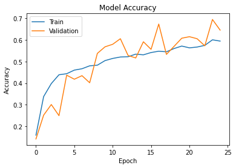

```python
plt.plot(history.history["accuracy"])
plt.plot(history.history["val_accuracy"])
plt.title("Model Accuracy")
plt.ylabel("Accuracy")
plt.xlabel("Epoch")
plt.legend(["Train", "Validation"], loc="upper left")
plt.show()
```

##### Observations:

- Compared with model1, model2 is not that overfit.
- The accuracy on trian data is 0.5942 and on validation data is 0.6449, which is low but there is not much difference between these datasets.

```python
accuracy = model2.evaluate(X_test_normalized, y_test_encoded, verbose=2)
```

```
15/15 - 0s - loss: 1.1035 - accuracy: 0.6253 - 441ms/epoch - 29ms/step
```

```python
# Here we would get the output as probablities for each category
y_pred = model2.predict(X_test_normalized)
```

#### Plotting the Confusion Matrix diagram

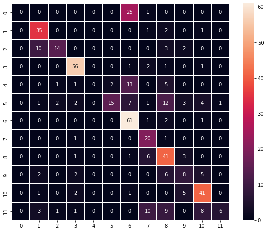

```python
# Obtaining the categorical values from y_test_encoded and y_pred
y_pred_arg = np.argmax(y_pred, axis=1)
y_test_arg = np.argmax(y_test_encoded, axis=1)

# Plotting the Confusion Matrix using confusion matrix() function which is also predefined tensorflow module
confusion_matrix = tf.math.confusion_matrix(y_test_arg, y_pred_arg)
f, ax = plt.subplots(figsize=(10, 8))
sns.heatmap(confusion_matrix, annot=True, linewidths=0.4, fmt="d", square=True, ax=ax)
plt.show()
```

##### Model3

- On the above models I used class weights since dataset is imbalanced.
- I want to run one more model (model3) without applying class weights to see what I can learn from it.

```python
# Clearing backend
from tensorflow.keras import backend

backend.clear_session()
```

```python
# Fixing the seed for random number generators
import random

np.random.seed(42)
random.seed(42)
tf.random.set_seed(42)
```

```python
# Intializing a sequential model3
model3 = Sequential()

# Adding first conv layer with 64 filters and kernel size 3x3 , padding 'same' provides the output size same as the input size
# Input_shape denotes input image dimension of images
model3.add(
    Conv2D(64, (3, 3), activation="relu", padding="same", input_shape=(64, 64, 3))
)

# Adding max pooling to reduce the size of output of first conv layer
model3.add(MaxPooling2D((2, 2), padding="same"))

model3.add(Conv2D(32, (3, 3), activation="relu", padding="same"))
model3.add(MaxPooling2D((2, 2), padding="same"))


# flattening the output of the conv layer after max pooling to make it ready for creating dense connections
model3.add(Flatten())

# Adding a fully connected dense layer with 100 neurons
model3.add(Dense(16, activation="relu"))
model3.add(Dropout(0.3))

# Adding the output layer with 10 neurons and activation functions as softmax since this is a multi-class classification problem
model3.add(Dense(12, activation="softmax"))


opt = Adam()
# Compile model3
model3.compile(optimizer=opt, loss="categorical_crossentropy", metrics=["accuracy"])

# Generating the summary of the model3
model3.summary()
```

```
Model: "sequential"
_________________________________________________________________
 Layer (type)                Output Shape              Param #
=================================================================
 conv2d (Conv2D)             (None, 64, 64, 64)        1792

 max_pooling2d (MaxPooling2D  (None, 32, 32, 64)       0
 )

 conv2d_1 (Conv2D)           (None, 32, 32, 32)        18464

 max_pooling2d_1 (MaxPooling  (None, 16, 16, 32)       0
 2D)

 flatten (Flatten)           (None, 8192)              0

 dense (Dense)               (None, 16)                131088

 dropout (Dropout)           (None, 16)                0

 dense_1 (Dense)             (None, 12)                204

=================================================================
Total params: 151,548
Trainable params: 151,548
Non-trainable params: 0
_________________________________________________________________
```

```python
history_1 = model3.fit(
    X_train_normalized,
    y_train_encoded,
    epochs=30,
    validation_split=0.1,
    # shuffle=True,
    batch_size=32,
    verbose=2,
)
```

```
109/109 - 10s - loss: 2.4705 - accuracy: 0.1147 - val_loss: 2.4548 - val_accuracy: 0.1429 - 10s/epoch - 93ms/step
109/109 - 9s - loss: 2.4389 - accuracy: 0.1337 - val_loss: 2.4064 - val_accuracy: 0.1403 - 9s/epoch - 87ms/step
109/109 - 9s - loss: 2.3783 - accuracy: 0.1606 - val_loss: 2.3524 - val_accuracy: 0.1506 - 9s/epoch - 85ms/step
109/109 - 10s - loss: 2.3187 - accuracy: 0.1950 - val_loss: 2.2441 - val_accuracy: 0.2156 - 10s/epoch - 87ms/step
109/109 - 10s - loss: 2.2677 - accuracy: 0.2002 - val_loss: 2.2584 - val_accuracy: 0.2208 - 10s/epoch - 94ms/step
109/109 - 10s - loss: 2.2328 - accuracy: 0.2149 - val_loss: 2.1649 - val_accuracy: 0.2494 - 10s/epoch - 87ms/step
109/109 - 10s - loss: 2.2186 - accuracy: 0.2135 - val_loss: 2.1150 - val_accuracy: 0.2416 - 10s/epoch - 89ms/step
109/109 - 10s - loss: 2.1894 - accuracy: 0.2195 - val_loss: 2.0911 - val_accuracy: 0.2494 - 10s/epoch - 95ms/step
109/109 - 10s - loss: 2.1787 - accuracy: 0.2233 - val_loss: 2.1025 - val_accuracy: 0.2494 - 10s/epoch - 94ms/step
109/109 - 11s - loss: 2.1661 - accuracy: 0.2244 - val_loss: 2.0666 - val_accuracy: 0.2545 - 11s/epoch - 97ms/step
109/109 - 10s - loss: 2.1740 - accuracy: 0.2267 - val_loss: 2.0586 - val_accuracy: 0.2468 - 10s/epoch - 93ms/step
109/109 - 10s - loss: 2.1604 - accuracy: 0.2253 - val_loss: 2.0479 - val_accuracy: 0.2545 - 10s/epoch - 88ms/step
109/109 - 10s - loss: 2.1463 - accuracy: 0.2267 - val_loss: 2.0377 - val_accuracy: 0.2519 - 10s/epoch - 89ms/step
109/109 - 10s - loss: 2.1393 - accuracy: 0.2291 - val_loss: 2.0552 - val_accuracy: 0.2519 - 10s/epoch - 87ms/step
109/109 - 10s - loss: 2.1252 - accuracy: 0.2314 - val_loss: 2.0391 - val_accuracy: 0.2545 - 10s/epoch - 88ms/step
109/109 - 10s - loss: 2.1282 - accuracy: 0.2302 - val_loss: 2.0229 - val_accuracy: 0.2597 - 10s/epoch - 87ms/step
109/109 - 10s - loss: 2.1270 - accuracy: 0.2305 - val_loss: 2.0196 - val_accuracy: 0.2571 - 10s/epoch - 87ms/step
109/109 - 10s - loss: 2.1231 - accuracy: 0.2328 - val_loss: 2.0316 - val_accuracy: 0.2623 - 10s/epoch - 87ms/step
109/109 - 10s - loss: 2.1144 - accuracy: 0.2348 - val_loss: 2.0433 - val_accuracy: 0.2623 - 10s/epoch - 89ms/step
109/109 - 10s - loss: 2.1246 - accuracy: 0.2296 - val_loss: 2.0021 - val_accuracy: 0.2519 - 10s/epoch - 89ms/step
109/109 - 10s - loss: 2.1292 - accuracy: 0.2262 - val_loss: 1.9937 - val_accuracy: 0.2545 - 10s/epoch - 88ms/step
109/109 - 9s - loss: 2.1132 - accuracy: 0.2319 - val_loss: 1.9900 - val_accuracy: 0.2545 - 9s/epoch - 87ms/step
109/109 - 10s - loss: 2.1065 - accuracy: 0.2374 - val_loss: 1.9927 - val_accuracy: 0.2571 - 10s/epoch - 90ms/step
109/109 - 10s - loss: 2.1180 - accuracy: 0.2351 - val_loss: 1.9805 - val_accuracy: 0.2519 - 10s/epoch - 87ms/step
109/109 - 10s - loss: 2.1186 - accuracy: 0.2337 - val_loss: 1.9856 - val_accuracy: 0.2545 - 10s/epoch - 89ms/step
109/109 - 10s - loss: 2.1279 - accuracy: 0.2247 - val_loss: 1.9888 - val_accuracy: 0.2571 - 10s/epoch - 89ms/step
109/109 - 10s - loss: 2.1192 - accuracy: 0.2343 - val_loss: 1.9818 - val_accuracy: 0.2623 - 10s/epoch - 87ms/step
109/109 - 10s - loss: 2.0913 - accuracy: 0.2386 - val_loss: 1.9744 - val_accuracy: 0.2597 - 10s/epoch - 94ms/step
109/109 - 9s - loss: 2.0981 - accuracy: 0.2369 - val_loss: 1.9753 - val_accuracy: 0.2623 - 9s/epoch - 85ms/step
109/109 - 9s - loss: 2.0978 - accuracy: 0.2369 - val_loss: 1.9934 - val_accuracy: 0.2597 - 9s/epoch - 86ms/step
```

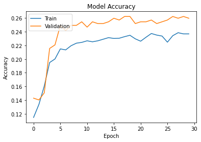

```python
plt.plot(history_1.history["accuracy"])
plt.plot(history_1.history["val_accuracy"])
plt.title("Model Accuracy")
plt.ylabel("Accuracy")
plt.xlabel("Epoch")
plt.legend(["Train", "Validation"], loc="upper left")
plt.show()
```

#### Observations:

```python
accuracy = model3.evaluate(X_test_normalized, y_test_encoded, verbose=2)
```

```
15/15 - 0s - loss: 2.0066 - accuracy: 0.2863 - 395ms/epoch - 26ms/step
```

- The accuracy on test data is 0.2863

```python
# Here we would get the output as probablities for each category
y_pred = model3.predict(X_test_normalized)
```

```python
y_pred
```

```
array([[2.1769088e-02, 1.1005637e-01, 7.0183642e-02, ..., 6.4024441e-02,
        1.4231327e-01, 7.9261415e-02],
       [2.1769088e-02, 1.1005637e-01, 7.0183642e-02, ..., 6.4024441e-02,
        1.4231327e-01, 7.9261415e-02],
       [2.1769088e-02, 1.1005637e-01, 7.0183642e-02, ..., 6.4024441e-02,
        1.4231327e-01, 7.9261415e-02],
       ...,
       [1.9916049e-01, 4.2998542e-07, 8.8207303e-03, ..., 2.0538364e-07,
        3.0838530e-07, 7.6490372e-02],
       [2.1769088e-02, 1.1005637e-01, 7.0183642e-02, ..., 6.4024441e-02,
        1.4231327e-01, 7.9261415e-02],
       [2.1769088e-02, 1.1005637e-01, 7.0183642e-02, ..., 6.4024441e-02,
        1.4231327e-01, 7.9261415e-02]], dtype=float32)
```

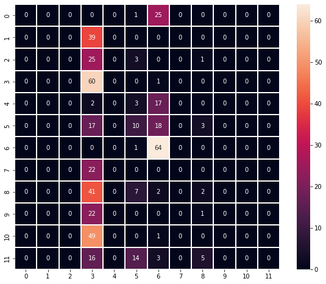

```python
# Obtaining the categorical values from y_test_encoded and y_pred
y_pred_arg = np.argmax(y_pred, axis=1)
y_test_arg = np.argmax(y_test_encoded, axis=1)

# Plotting the Confusion Matrix using confusion matrix() function which is also predefined tensorflow module
confusion_matrix = tf.math.confusion_matrix(y_test_arg, y_pred_arg)
f, ax = plt.subplots(figsize=(10, 8))
sns.heatmap(confusion_matrix, annot=True, linewidths=0.4, fmt="d", square=True, ax=ax)
plt.show()
```

#### Transfer Learning using VGG16

- For training VGG16, we will directly use the convolutional and pooling layers and freeze their weights i.e. no training will be done on them.
- For classification, we will replace the existing fully-connected layers with FC layers created specifically for our problem.

##### Model4 - Vgg_Model

```python
from tensorflow.keras.models import Model
from keras.applications.vgg16 import VGG16

vgg_model = VGG16(weights="imagenet", include_top=False, input_shape=(64, 64, 3))
vgg_model.summary()
```

```
Model: "vgg16"
_________________________________________________________________
 Layer (type)                Output Shape              Param #
=================================================================
 input_1 (InputLayer)        [(None, 64, 64, 3)]       0

 block1_conv1 (Conv2D)       (None, 64, 64, 64)        1792

 block1_conv2 (Conv2D)       (None, 64, 64, 64)        36928

 block1_pool (MaxPooling2D)  (None, 32, 32, 64)        0

 block2_conv1 (Conv2D)       (None, 32, 32, 128)       73856

 block2_conv2 (Conv2D)       (None, 32, 32, 128)       147584

 block2_pool (MaxPooling2D)  (None, 16, 16, 128)       0

 block3_conv1 (Conv2D)       (None, 16, 16, 256)       295168

 block3_conv2 (Conv2D)       (None, 16, 16, 256)       590080

 block3_conv3 (Conv2D)       (None, 16, 16, 256)       590080

 block3_pool (MaxPooling2D)  (None, 8, 8, 256)         0

 block4_conv1 (Conv2D)       (None, 8, 8, 512)         1180160

 block4_conv2 (Conv2D)       (None, 8, 8, 512)         2359808

 block4_conv3 (Conv2D)       (None, 8, 8, 512)         2359808

 block4_pool (MaxPooling2D)  (None, 4, 4, 512)         0

 block5_conv1 (Conv2D)       (None, 4, 4, 512)         2359808

 block5_conv2 (Conv2D)       (None, 4, 4, 512)         2359808

 block5_conv3 (Conv2D)       (None, 4, 4, 512)         2359808

 block5_pool (MaxPooling2D)  (None, 2, 2, 512)         0

=================================================================
Total params: 14,714,688
Trainable params: 14,714,688
Non-trainable params: 0
_________________________________________________________________
```

```python
# Making all the layers of the VGG model non-trainable. i.e. freezing them
for layer in vgg_model.layers:
    layer.trainable = False
```

```python
model4 = Sequential()

# Adding the convolutional part of the VGG16 model from above
model4.add(vgg_model)

# Flattening the output of the VGG16 model because it is from a convolutional layer
model4.add(Flatten())

# Adding a dense output layer
model4.add(Dense(32, activation="relu"))
model4.add(Dropout(0.2))
model4.add(Dense(16, activation="relu"))
model4.add(Dense(12, activation="softmax"))
opt = Adam()
# Compile model
model4.compile(optimizer=opt, loss="categorical_crossentropy", metrics=["accuracy"])

# Generating the summary of the model
model4.summary()
```

```
Model: "sequential_1"
_________________________________________________________________
 Layer (type)                Output Shape              Param #
=================================================================
 vgg16 (Functional)          (None, 2, 2, 512)         14714688

 flatten_1 (Flatten)         (None, 2048)              0

 dense_2 (Dense)             (None, 32)                65568

 dropout_1 (Dropout)         (None, 32)                0

 dense_3 (Dense)             (None, 16)                528

 dense_4 (Dense)             (None, 12)                204

=================================================================
Total params: 14,780,988
Trainable params: 66,300
Non-trainable params: 14,714,688
_________________________________________________________________
```

```python
# Epochs
epochs = 25
# Batch size
batch_size = 64

history_vgg16 = model4.fit(
    train_datagen.flow(
        X_train_normalized,
        y_train_encoded,
        batch_size=batch_size,
        seed=42,
        shuffle=False,
    ),
    epochs=epochs,
    steps_per_epoch=X_train_normalized.shape[0] // batch_size,
    validation_data=(X_val_normalized, y_val_encoded),
    class_weight=class_weights,
    verbose=1,
)
```

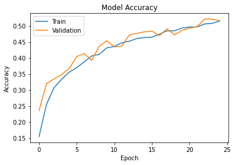

```python
plt.plot(history_vgg16.history["accuracy"])
plt.plot(history_vgg16.history["val_accuracy"])
plt.title("Model Accuracy")
plt.ylabel("Accuracy")
plt.xlabel("Epoch")
plt.legend(["Train", "Validation"], loc="upper left")
plt.show()
```

##### Observations:

```python
accuracy = model4.evaluate(X_test_normalized, y_test_encoded, verbose=2)
```

```
15/15 - 4s - loss: 1.3364 - accuracy: 0.5242 - 4s/epoch - 290ms/step
```

- The accuracy on test data is ~.50
- The accuracy is almost same on all three datasets.

```python
# Here we would get the output as probablities for each category
y_pred = model4.predict(X_test_normalized)
```

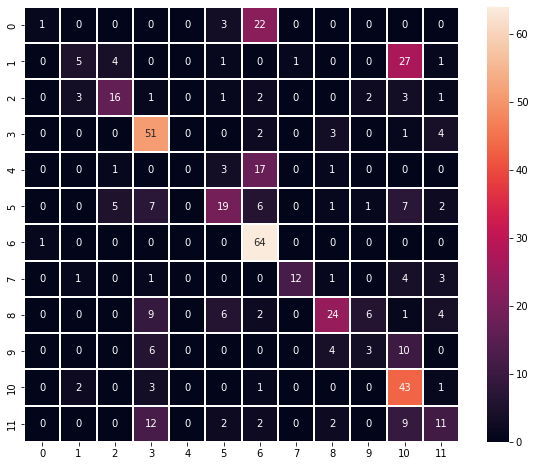

```python
# Obtaining the categorical values from y_test_encoded and y_pred
y_pred_arg = np.argmax(y_pred, axis=1)
y_test_arg = np.argmax(y_test_encoded, axis=1)

# Plotting the Confusion Matrix using confusion matrix() function which is also predefined tensorflow module
confusion_matrix = tf.math.confusion_matrix(y_test_arg, y_pred_arg)
f, ax = plt.subplots(figsize=(10, 8))
sns.heatmap(confusion_matrix, annot=True, linewidths=0.4, fmt="d", square=True, ax=ax)
plt.show()
```

##### Observations

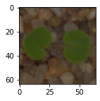

```
Predicted Label ['Small-flowered Cranesbill']
True Label Small-flowered Cranesbill
```

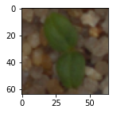

```
Predicted Label ['Cleavers']
True Label Cleavers
```

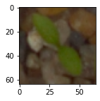

```
Predicted Label ['Common Chickweed']
True Label Common Chickweed
```

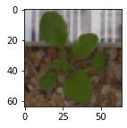

```
Predicted Label ['Shepherds Purse']
True Label Shepherds Purse
```

```python
# Visualizing the predicted and correct label of images from test data
plt.figure(figsize=(2, 2))
plt.imshow(X_test[2])
plt.show()
print(
    "Predicted Label",
    enc.inverse_transform(model2.predict((X_test_normalized[2].reshape(1, 64, 64, 3)))),
)  # reshaping the input image as we are only trying to predict using a single image
print(
    "True Label", enc.inverse_transform(y_test_encoded)[2]
)  # using inverse_transform() to get the output label from the output vector

plt.figure(figsize=(2, 2))
plt.imshow(X_test[33])
plt.show()
print(
    "Predicted Label",
    enc.inverse_transform(
        model2.predict((X_test_normalized[33].reshape(1, 64, 64, 3)))
    ),
)  # reshaping the input image as we are only trying to predict using a single image
print(
    "True Label", enc.inverse_transform(y_test_encoded)[33]
)  # using inverse_transform() to get the output label from the output vector

plt.figure(figsize=(2, 2))
plt.imshow(X_test[59],)
plt.show()
print(
    "Predicted Label",
    enc.inverse_transform(
        model2.predict((X_test_normalized[59].reshape(1, 64, 64, 3)))
    ),
)  # reshaping the input image as we are only trying to predict using a single image
print(
    "True Label", enc.inverse_transform(y_test_encoded)[59]
)  # using inverse_transform() to get the output label from the output vector

plt.figure(figsize=(2, 2))
plt.imshow(X_test[36])
plt.show()
print(
    "Predicted Label",
    enc.inverse_transform(
        model2.predict((X_test_normalized[36].reshape(1, 64, 64, 3)))
    ),
)  # reshaping the input image as we are only trying to predict using a single image
print(
    "True Label", enc.inverse_transform(y_test_encoded)[36]
)  # using inverse_transform() to get the output label from the output vector
```

- In all above cases both Predicted Label and true label were matched.

### Conclusion

- We can observe from the confusion matrix of all the models that our Model2 was the best model. It has overfit but compared to other models , the overfit is not that much.
- When used model2 to predict images, Noted both actual and predicted images were matched.
- The test accuracy of the model2 is ~60%.
- Data Augmentation has also helped in improving the model2
- Transfer learning model (Vgg) did not help much, I'm suspecting this is due the dataset.What the learning moduel had (convolution filters) might not done proper job with the dataset. This could be due to images were not included in the learning module.
- If time is given and resources are not an issue, by applying few more dropout, batch normalization and other techniques, I could improve accuracy.